# Scraping data from Twitter’s Streaming API

Pablo Barbera

August 2nd, 2018

#### Authenticating

Before we can start collecting Twitter data, we need to create an OAuth token that will allow us to authenticate our connection and access our personal data.

After the new API changes, getting a new token requires submitting an application for a developer account, which may take a few days. For teaching purposes only, I will temporarily share one of my tokens with each of you, so that we can use the API without having to do the authentication.

However, if in the future you want to get your own token, here’s how you would do it:

Follow these steps to create your token:

1. Go to https://developer.twitter.com/en/apps and sign in.
2. If you don’t have a developer account, you will need to apply for one first. Fill in the application form and wait for a response.
3. Once it’s approved, click on “Create New App”. You will need to have a phone number associated with your account in order to be able to create a token.
4. Fill name, description, and website (it can be anything, even http://www.google.com). Make sure you leave ‘Callback URL’ empty.
5. Agree to user conditions.
6. From the “Keys and Access Tokens” tab, copy consumer key and consumer secret and paste below
7. Click on “Create my access token”, then copy and paste your access token and access token secret below

```r
library(ROAuth)
my_oauth <- list(consumer_key = "CONSUMER_KEY",
   consumer_secret = "CONSUMER_SECRET",
   access_token="ACCESS_TOKEN",
   access_token_secret = "ACCESS_TOKEN_SECRET")
save(my_oauth, file="~/my_oauth")
```

```r
load("~/my_oauth")
```

What can go wrong here? Make sure all the consumer and token keys are pasted here as is, without any additional space character. If you don’t see any output in the console after running the code above, that’s a good sign.

Note that I saved the list as a file in my hard drive. That will save us some time later on, but you could also just re-run the code in lines 22 to 27 before conecting to the API in the future.

To check that it worked, try running the line below:

```r
library(tweetscores)
getUsers(screen_names="LSEnews", oauth = my_oauth)[[1]]$screen_name
```

```
## [1] "LSEnews"
```

If this displays `LSEnews` then we’re good to go!

#### Collecting data from Twitter’s Streaming API

Collecting tweets filtering by keyword:

```r
library(streamR)
filterStream(file.name="~/data/trump-streaming-tweets.json", track="trump",
    timeout=20, oauth=my_oauth)
```

```
## Capturing tweets...
```

```
## Connection to Twitter stream was closed after 20 seconds with up to 550 tweets downloaded.
```

Note the options: - `file.name` indicates the file in your disk where the tweets will be downloaded  
- `track` is the keyword(s) mentioned in the tweets we want to capture. - `timeout` is the number of seconds that the connection will remain open  
- `oauth` is the OAuth token we are using

Once it has finished, we can open it in R as a data frame with the `parseTweets` function

```r
tweets <- parseTweets("~/data/trump-streaming-tweets.json")
```

```
## 326 tweets have been parsed.
```

```r
tweets[1,]
```

```
##                                                                                                                                           text
## 1 RT @tonyposnanski: Lebron James has done more for education than Betsy DeVos, more for charity than Donald Trump, and more for inner cities…
##   retweet_count favorite_count favorited truncated              id_str
## 1         13580          43680     FALSE     FALSE 1024241236054441984
##   in_reply_to_screen_name
## 1                    <NA>
##                                                                               source
## 1 <a href="http://twitter.com/download/iphone" rel="nofollow">Twitter for iPhone</a>
##   retweeted                     created_at in_reply_to_status_id_str
## 1     FALSE Tue Jul 31 10:31:54 +0000 2018                      <NA>
##   in_reply_to_user_id_str lang listed_count verified     location
## 1                    <NA>   en           24    FALSE Palmdale, CA
##   user_id_str
## 1   328332576
##                                                                                                             description
## 1 J ❤️ B 06/19/15. Jaquelyn Arce is my one & only . Basketball player Video Gamer Future Successor. Jeep Owner Laker Fan
##   geo_enabled                user_created_at statuses_count
## 1        TRUE Sun Jul 03 05:07:08 +0000 2011          73601
##   followers_count favourites_count protected user_url            name
## 1             586             9985     FALSE     <NA> Brian Dominguez
##   time_zone user_lang utc_offset friends_count screen_name country_code
## 1        NA        en         NA           451      BD23s_         <NA>
##   country place_type full_name place_name place_id place_lat place_lon lat
## 1    <NA>         NA      <NA>       <NA>     <NA>       NaN       NaN  NA
##   lon expanded_url  url
## 1  NA         <NA> <NA>
```

If we want, we could also export it to a csv file to be opened later with Excel

```r
write.csv(tweets, file="~/data/trump-streaming-tweets.csv", row.names=FALSE)
```

And this is how we would capture tweets mentioning multiple keywords:

```r
filterStream(file.name="~/data/politics-tweets.json",
    track=c("graham", "sessions", "trump", "clinton"),
    tweets=20, oauth=my_oauth)
```

Note that here I choose a different option, `tweets`, which indicates how many tweets (approximately) the function should capture before we close the connection to the Twitter API.

This second example shows how to collect tweets filtering by location instead. In other words, we can set a geographical box and collect only the tweets that are coming from that area.

For example, imagine we want to collect tweets from the United States. The way to do it is to find two pairs of coordinates (longitude and latitude) that indicate the southwest corner AND the northeast corner. Note the reverse order: it’s not (lat, long), but (long, lat).

In the case of the US, it would be approx. (-125,25) and (-66,50). How to find these coordinates? I use: `http://itouchmap.com/latlong.html`

```r
filterStream(file.name="~/data/tweets_geo.json", locations=c(-125, 25, -66, 50),
    timeout=30, oauth=my_oauth)
```

```
## Capturing tweets...
```

```
## Connection to Twitter stream was closed after 30 seconds with up to 229 tweets downloaded.
```

We can do as before and open the tweets in R

```r
tweets <- parseTweets("~/data/tweets_geo.json")
```

```
## 199 tweets have been parsed.
```

And use the maps library to see where most tweets are coming from. Note that there are two types of geographic information on tweets: `lat`/`lon` (from geolocated tweets) and `place_lat` and `place_lon` (from tweets with place information). We will work with whatever is available.

```r
library(maps)
tweets$lat <- ifelse(is.na(tweets$lat), tweets$place_lat, tweets$lat)
tweets$lon <- ifelse(is.na(tweets$lon), tweets$place_lon, tweets$lon)
tweets <- tweets[!is.na(tweets$lat),]
states <- map.where("state", tweets$lon, tweets$lat)
head(sort(table(states), decreasing=TRUE))
```

```
## states
##        new york:main           california new york:long island
##                   36                   15                   11
##                texas              georgia           new jersey
##                   11                    9                    9
```

We can also prepare a map of the exact locations of the tweets.

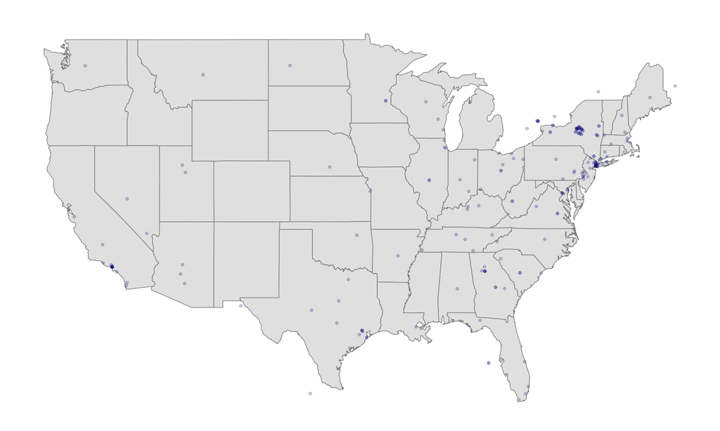

```r
library(ggplot2)
## First create a data frame with the map data
map.data <- map_data("state")

# And we use ggplot2 to draw the map:
# 1) map base
ggplot(map.data) + geom_map(aes(map_id = region), map = map.data, fill = "grey90",
    color = "grey50", size = 0.25) + expand_limits(x = map.data$long, y = map.data$lat) +
    # 2) limits for x and y axis
    scale_x_continuous(limits=c(-125,-66)) + scale_y_continuous(limits=c(25,50)) +
    # 3) adding the dot for each tweet
    geom_point(data = tweets,
    aes(x = lon, y = lat), size = 1, alpha = 1/5, color = "darkblue") +
    # 4) removing unnecessary graph elements
    theme(axis.line = element_blank(),
        axis.text = element_blank(),
        axis.ticks = element_blank(),
        axis.title = element_blank(),
        panel.background = element_blank(),
        panel.border = element_blank(),
        panel.grid.major = element_blank(),
        panel.grid.minor = element_blank(),
        plot.background = element_blank())
```

And here’s how to extract the edges of a network of retweets (at least one possible way of doing it):

```r
tweets <- parseTweets("~/data/trump-streaming-tweets.json")
```

```
## 326 tweets have been parsed.
```

```r
# subset only RTs
rts <- tweets[grep("RT @", tweets$text),]

edges <- data.frame(
  node1 = rts$screen_name,
  node2 = gsub('.*RT @([a-zA-Z0-9_]+):? ?.*', rts$text, repl="\\1"),
  stringsAsFactors=F
)

library(igraph)
g <- graph_from_data_frame(d=edges, directed=TRUE)
```

Finally, it’s also possible to collect a random sample of tweets. That’s what the “sampleStream” function does:

```r
sampleStream(file.name="~/data/tweets_random.json", timeout=30, oauth=my_oauth)
```

```
## Capturing tweets...
```

```
## Connection to Twitter stream was closed after 30 seconds with up to 1986 tweets downloaded.
```

Here I’m collecting 30 seconds of tweets. And once again, to open the tweets in R…

```r
tweets <- parseTweets("~/data/tweets_random.json")
```

```
## 1096 tweets have been parsed.
```

What is the most retweeted tweet?

```r
tweets[which.max(tweets$retweet_count),]
```

```
##                                                                              text
## 823 RT @Jon_Christian: Bless this doggo who stole a GoPro https://t.co/tZwVdniJoQ
##     retweet_count favorite_count favorited truncated              id_str
## 823        293438         791017     FALSE     FALSE 1024241541605466112
##     in_reply_to_screen_name
## 823                    <NA>
##                                                                                 source
## 823 <a href="http://twitter.com/download/iphone" rel="nofollow">Twitter for iPhone</a>
##     retweeted                     created_at in_reply_to_status_id_str
## 823     FALSE Tue Jul 31 10:33:07 +0000 2018                      <NA>
##     in_reply_to_user_id_str lang listed_count verified location
## 823                    <NA>   en            2    FALSE     <NA>
##     user_id_str description geo_enabled                user_created_at
## 823  4883255627        <NA>        TRUE Sat Feb 06 22:49:15 +0000 2016
##     statuses_count followers_count favourites_count protected user_url
## 823          16393             180            10840     FALSE     <NA>
##       name time_zone user_lang utc_offset friends_count    screen_name
## 823 momone        NA        en         NA           178 BibitefFaustin
##     country_code country place_type full_name place_name place_id
## 823         <NA>    <NA>         NA      <NA>       <NA>     <NA>
##     place_lat place_lon lat lon expanded_url  url
## 823       NaN       NaN  NA  NA         <NA> <NA>
```

What are the most popular hashtags at the moment? We’ll use regular expressions to extract hashtags.

```r
library(stringr)
ht <- str_extract_all(tweets$text, "#(\\d|\\w)+")
ht <- unlist(ht)
head(sort(table(ht), decreasing = TRUE))
```

```
## ht
##      #VRoid #MTVHottest     #워너원          #4   #WANNAONE     #박우진
##          16           7           4           3           3           3
```

And who are the most frequently mentioned users?

```r
users <- str_extract_all(tweets$text, '@[a-zA-Z0-9_]+')
users <- unlist(users)
head(sort(table(users), decreasing = TRUE))
```

```
## users
##       @BTS_twt   @weareoneEXO       @YouTube @B1A4_gongchan   @alhajitekno
##              6              4              4              3              2
##   @belldelagua
##              2
```

How many tweets mention Justin Bieber?

```r
length(grep("bieber", tweets$text, ignore.case=TRUE))
```

```
## [1] 0
```

These are toy examples, but for large files with tweets in JSON format, there might be faster ways to parse the data. For example, the `ndjson` package offers a robust and fast way to parse JSON data:

```r
library(ndjson)
json <- stream_in("~/data/tweets_geo.json")
json
```

```
## Source: local data table [199 x 783]
##
## # A tibble: 199 x 783
##    contributors coordinates                     created_at
##           <int>       <int>                          <chr>
##  1           NA          NA Tue Jul 31 10:32:15 +0000 2018
##  2           NA          NA Tue Jul 31 10:32:16 +0000 2018
##  3           NA          NA Tue Jul 31 10:32:16 +0000 2018
##  4           NA          NA Tue Jul 31 10:32:16 +0000 2018
##  5           NA          NA Tue Jul 31 10:32:16 +0000 2018
##  6           NA          NA Tue Jul 31 10:32:16 +0000 2018
##  7           NA          NA Tue Jul 31 10:32:16 +0000 2018
##  8           NA          NA Tue Jul 31 10:32:17 +0000 2018
##  9           NA          NA Tue Jul 31 10:32:17 +0000 2018
## 10           NA          NA Tue Jul 31 10:32:17 +0000 2018
## # ... with 189 more rows, and 780 more variables:
## #   display_text_range.0 <dbl>, display_text_range.1 <dbl>,
## #   entities.hashtags <int>, entities.media.0.display_url <chr>,
## #   entities.media.0.expanded_url <chr>, entities.media.0.id <dbl>,
## #   entities.media.0.id_str <chr>, entities.media.0.indices.0 <dbl>,
## #   entities.media.0.indices.1 <dbl>, entities.media.0.media_url <chr>,
## #   entities.media.0.media_url_https <chr>,
## #   entities.media.0.sizes.large.h <dbl>,
## #   entities.media.0.sizes.large.resize <chr>,
## #   entities.media.0.sizes.large.w <dbl>,
## #   entities.media.0.sizes.medium.h <dbl>,
## #   entities.media.0.sizes.medium.resize <chr>,
## #   entities.media.0.sizes.medium.w <dbl>,
## #   entities.media.0.sizes.small.h <dbl>,
## #   entities.media.0.sizes.small.resize <chr>,
## #   entities.media.0.sizes.small.w <dbl>,
## #   entities.media.0.sizes.thumb.h <dbl>,
## #   entities.media.0.sizes.thumb.resize <chr>,
## #   entities.media.0.sizes.thumb.w <dbl>, entities.media.0.type <chr>,
## #   entities.media.0.url <chr>, entities.symbols <int>,
## #   entities.urls <int>, entities.user_mentions <int>,
## #   extended_entities.media.0.display_url <chr>,
## #   extended_entities.media.0.expanded_url <chr>,
## #   extended_entities.media.0.id <dbl>,
## #   extended_entities.media.0.id_str <chr>,
```

[output cut: 30 more lines]

```
## #   place.bounding_box.coordinates.0.1.0 <dbl>,
## #   place.bounding_box.coordinates.0.1.1 <dbl>,
## #   place.bounding_box.coordinates.0.2.0 <dbl>,
## #   place.bounding_box.coordinates.0.2.1 <dbl>,
## #   place.bounding_box.coordinates.0.3.0 <dbl>,
## #   place.bounding_box.coordinates.0.3.1 <dbl>,
## #   place.bounding_box.type <chr>, place.country <chr>,
## #   place.country_code <chr>, place.full_name <chr>, place.id <chr>,
## #   place.name <chr>, place.place_type <chr>, place.url <chr>,
## #   possibly_sensitive <lgl>, quote_count <dbl>, reply_count <dbl>,
## #   retweet_count <dbl>, retweeted <lgl>, source <chr>, text <chr>,
## #   timestamp_ms <chr>, truncated <lgl>, user.contributors_enabled <lgl>,
## #   user.created_at <chr>, user.default_profile <lgl>,
## #   user.default_profile_image <lgl>, user.description <chr>,
## #   user.favourites_count <dbl>, ...
```